# Abacavirinol

## Inferential Results

```
## Pearson's Chi-squared test with Yates' continuity correction
##
## Observed Counts:
##         treatment
## infected drug placebo
##     aids   46     105
##     none 1066    1072
##
## Counts Expected by Null:
##         treatment
## infected    drug placebo
##     aids   73.36   77.64
##     none 1038.64 1099.36
##
## Contributions to the chi-square statistic:
##         treatment
## infected  drug placebo
##     aids 10.20    9.64
##     none  0.72    0.68
##
##
## Chi-Square Statistic = 20.4718
## Degrees of Freedom of the table = 1
## P-Value = 0
```

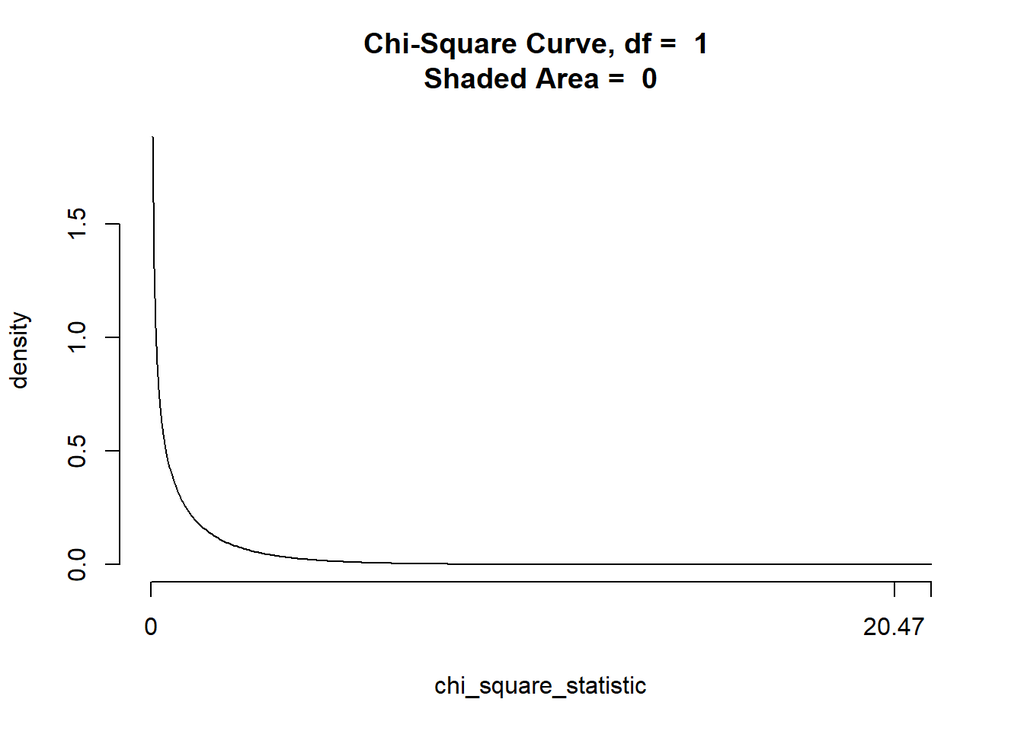

```r
chisqtestGC(resultsMale, graph = TRUE)
```

```r
fisher.test(resultsMale)
```

```
##
##  Fisher's Exact Test for Count Data
##
## data:  resultsMale
## p-value = 4.352e-06
## alternative hypothesis: true odds ratio is not equal to 1
## 95 percent confidence interval:
##  0.3013934 0.6360948
## sample estimates:
## odds ratio
##  0.4407101
```

According to the chi-squared test it shows that 46 people who took the drug ended up with aids while 1066 did not have aids. Then 105 people who took the placebo ended up with aids while 1072 did not. The chi-squared test also gave us a p-value of 0 which is enough to reject the null hypothesis. Although, we want to make sure of the p-value so that’s where the fisher test come in and gives us a p-value of 0.000004 which means we can reject the null hypothesis.

# Discussion and Conclusion

If we just look at the bar graph it seems that the drug works, even better than the graph of the whole and almost as good as it did with the drug users. Although, we need to take a closer look at the data to make sure what we are seeing is really true, because often times graphs can be very misleading. According to very basic statistical data shows that 30.46% of people with aids took the drug while 69.54%% of people took the placebo. Now that’s roughly about 40% difference. Let’s dig a little bit deeper 46 out of 1112 people who took the drug ended up with aids. While 105 out of 1177 people who took the placebo ended up with aids. Now that shows that the drug is working right? Lets keep going according to the Chi-squared test we have a p-value of 0 and the fisher test gives off a p-value of 0.000004. Both these values are far from the .05 that means we can reject the null hypothesis. Which means the drug works.

### Female

## Results

This is the results we got for the Females, we have two subdivisions for the results. First the graphical data containing a bar graph. Then the numerical data where we have the basic numerical data and some more advanced inferential data I.E a chisqtest and a fisher.t test.

## Descriptive Results

### Graphical Descriptive Results

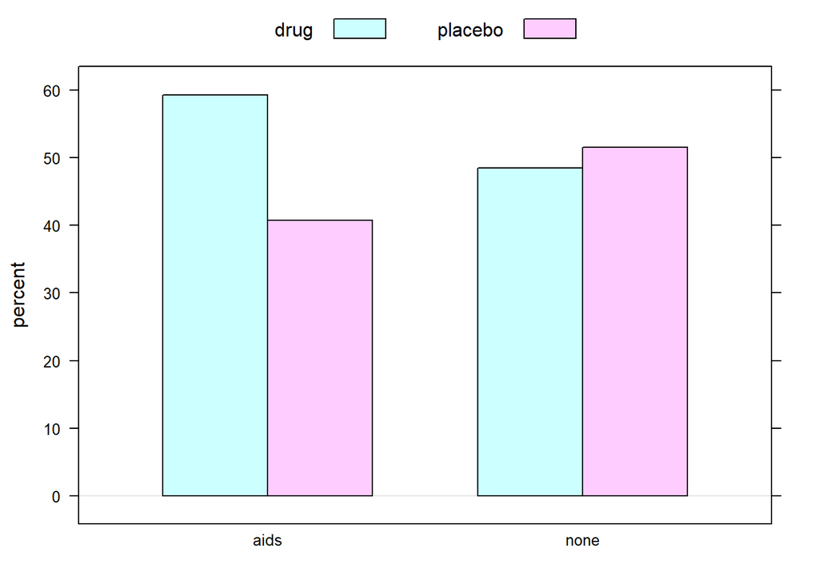

```r
resultsFemale <- xtabs(~infected+treatment,data=female)
barchartGC(resultsFemale,type = "percent")
```

### Numerical Descriptive Results

```r
colPerc(resultsFemale)
```

```
##         treatment
## infected   drug placebo
##    aids    3.96    2.59
##    none   96.04   97.41
##    Total 100.00  100.00
```

```r
rowPerc(resultsFemale)
```

```
##         treatment
## infected   drug placebo  Total
##     aids  59.30   40.70 100.00
##     none  48.47   51.53 100.00
```

According to these statstical results from colperc it shows that 3.96% that took the drug ended up with aids, while 96.04% didn’t. Then 2.59% who took the placebo ended up with aids while 97.41% didnt. Then in the rowperc test it shows that 59.30% of people with aids took the drug while 40.70% of people took the placebo. Then 48.47% of people who dont have aids took the drug while 51.53% took the placebo.

## Inferential Results

```
## Pearson's Chi-squared test with Yates' continuity correction
##
## Observed Counts:
##         treatment
## infected drug placebo
##     aids   51      35
##     none 1237    1315
##
## Counts Expected by Null:
##         treatment
## infected    drug placebo
##     aids   41.99   44.01
##     none 1246.01 1305.99
##
## Contributions to the chi-square statistic:
##         treatment
## infected drug placebo
##     aids 1.93    1.84
##     none 0.07    0.06
##
##
## Chi-Square Statistic = 3.4843
## Degrees of Freedom of the table = 1
## P-Value = 0.062
```

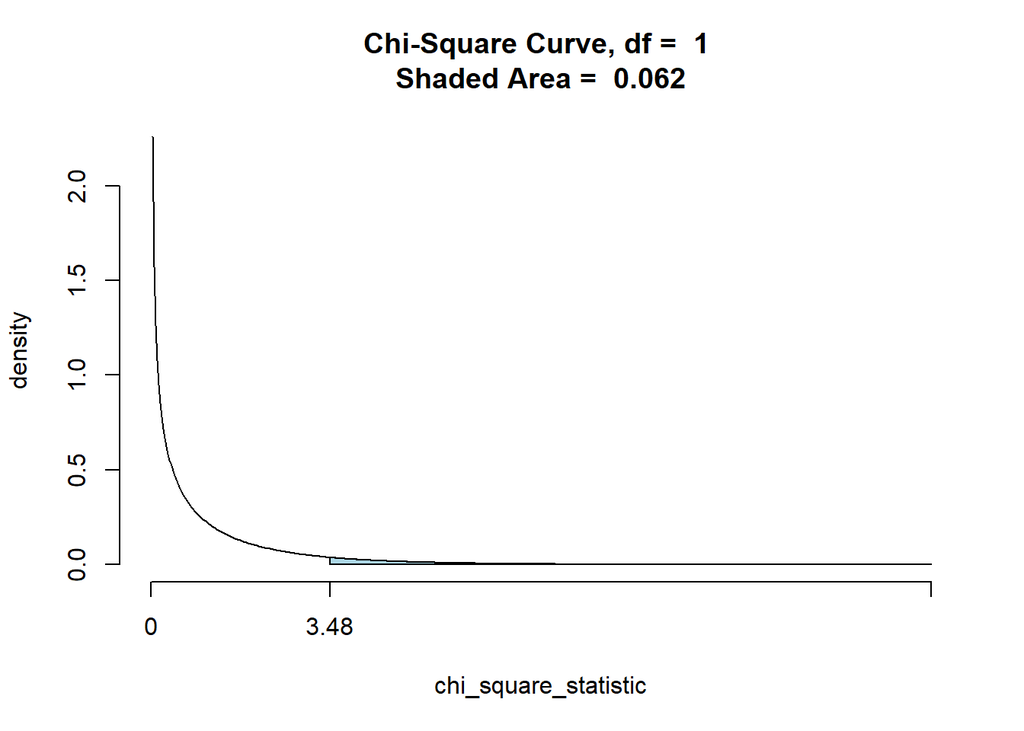

```r
chisqtestGC(resultsFemale, graph = TRUE)
```

```r
fisher.test(resultsFemale)
```

```
##
##  Fisher's Exact Test for Count Data
##
## data:  resultsFemale
## p-value = 0.04911
## alternative hypothesis: true odds ratio is not equal to 1
## 95 percent confidence interval:
##  0.980258 2.472003
## sample estimates:
## odds ratio
##   1.548757
```